# BIOSTAT 707 — Checkpoint 2: Mortality models on Set A

Author

Bowen Zhang (bz147)

## AI-use statement

I used ChatGPT to plan the modeling and validation design. I used OpenAI Codex to write and debug the R/Quarto/Pixi workflow, run analyses and automated checks, inspect figures, and help draft explanatory text. Automated checks examined data integrity, training-only preprocessing, cross-validation partitions, event coding, saved predictions, and reproducible execution. AI accelerated implementation and repeatable testing, but generated code required debugging. A rendering operation unexpectedly removed generated output; the submitted CP1 HTML was restored exactly from Git, and supporting outputs were regenerated with the recorded long/wide hashes checked. The complete original supporting-output manifest was lost, so full byte-for-byte restoration of those files cannot be established. The later audit also identified unstable generalized additive model (GAM) predictions caused by sparse-category separation. Detailed technical evidence is recorded in `docs/cp2-verification.md` and `docs/cp2-final-qa.md`. These automated checks do not establish clinical validity, causality, or independent external validation.

## 2.1 Modeling table and cleaning

The [PhysioNet/Computing in Cardiology Challenge 2012 dataset](https://physionet.org/content/challenge-2012/1.0.0/) contains intensive care unit (ICU) stays with observations over the first 48 hours. This analysis uses **Set A only**, with one row per stay. The two windows are columns: [0,24) and [24,48], so 24:00 begins the second window and 48:00 is included. All predictors become available only after this 48-hour observation window; this is not an admission-time prediction system.

Table 1. Reconstructed Set A modeling cohort.

| stays | wide_columns | deaths | death_percent | unique_ids |
| --- | --- | --- | --- | --- |
| 4000 | 455 | 554 | 13.85 | 4000 |

The reconstructed table has 4000 stays and 455 columns, including 554 deaths (13.85%). The death indicator is joined one-to-one by RecordID: source `In-hospital_death` maps to `In_hospital_death`, with 1 meaning death. Checks require complete binary outcomes, unique nonmissing IDs, equal patient/outcome ID sets, exact column names, 0–48-hour source times and consistent summary counts. A malformed stay or conflicting admission descriptor stops construction.

The pipeline reconstructs the wide table directly from `data/set-a/` and `data/Outcomes-a.txt`. It uses CP1 sentinel (`-1`) handling and hard-invalid rules in a copied analysis column, preserving original Value and Value_raw. Hard-invalid rules include negative nonmissing measurements, invalid categorical codes, and documented bounds for Glasgow Coma Score (GCS), inspired oxygen fraction, oxygen saturation and pH. CP1 soft zero/extreme flags are retained unless covered by the prespecified CP2 revision below. Positive maxima are review flags, not global deletion or winsorization thresholds.

Table 2. Record-level cleaning counts; different rules may overlap.

| rule | records |
| --- | --- |
| CP1 hard-invalid records | 33 |
| CP1 sentinel -1 records | 2223 |
| CP2 zero-height records | 0 |
| CP2 zero-weight records | 184 |

CP1 hard-invalid cleaning affects 33 records. CP2 additionally sets 184 zero-weight and 0 zero-height records to missing because zero body size is not usable. This happens before admission extraction and window aggregation, so repeated Weight values and valid counts change too. Other soft flags stay unchanged. Exact changed records, CP1 flags and admission extraction audits are saved under `output/cp2_*.csv`; CP1 source and generated results are preserved.

## 2.2 Predictors and eligibility

A positive allowlist supplies **449 candidate raw predictors** to elastic net and random forest: five admission descriptors and 444 summaries (37 variables × two windows × six statistics). The joined table’s 455 columns are not 455 predictors. RecordID, either target spelling, length of stay, survival, Simplified Acute Physiology Score I (SAPS-I) and Sequential Organ Failure Assessment (SOFA) are excluded from every model. Benchmark scores are held in a separate evaluation object.

Gender uses documented categories 0 = female, 1 = male; ICUType uses 1 = coronary care, 2 = cardiac surgery recovery, 3 = medical ICU, 4 = surgical ICU. Both are categorical. The dictionary abbreviations are coronary care unit (CCU), cardiac surgery recovery unit (CSRU), medical intensive care unit (MICU), and surgical intensive care unit (SICU). Liver enzyme abbreviations are alkaline phosphatase (ALP), alanine aminotransferase (ALT), and aspartate aminotransferase (AST). Other source labels are heart rate (HR), temperature (Temp), respiratory rate (RespRate), mean arterial pressure (MAP), blood urea nitrogen (BUN), and white blood cell count (WBC). Arterial blood pressure (ABP) uses diastolic (DiasABP) and systolic (SysABP) labels; NI prefixes identify non-invasive measurements (NIDiasABP, NIMAP, NISysABP). FiO2 is the inspired oxygen fraction; HCO3 is bicarbonate; HCT is hematocrit; PaCO2 and PaO2 are arterial carbon-dioxide and oxygen partial pressures; SaO2 is arterial oxygen saturation; MechVent denotes mechanical ventilation documentation. Unit IU/L means international units per liter. A count of zero means no valid measurement, not a measured laboratory value of zero. Counts can reflect monitoring, treatment decisions and patient condition; associations are not intervention effects.

Table 3. Broad predictor groups and retained full-data encoded columns.

| group | raw_candidates | rationale | encoded_retained |
| --- | --- | --- | --- |
| admission | 5 | Demographics, body size and care setting describe case mix. | 8 |
| count | 74 | Monitoring intensity and measurement absence can carry predictive information. | 74 |
| first | 74 | Earliest observed level describes the start of each window. | 72 |
| last | 74 | Latest observed level describes the end of each window. | 72 |
| max | 74 | Highest observed value summarizes physiological extremes. | 72 |
| mean | 74 | Average observed level summarizes window physiology. | 72 |
| min | 74 | Lowest observed value summarizes physiological extremes. | 72 |

The full-data broad design retains 442 encoded columns. Group counts show the effects of categorical dummy coding and training-only usability removal; eligibility is otherwise prespecified. No outcome-driven screening or rare-measurement threshold is used.

**Complete predictor dictionary: names, windows, definitions and units**

Table 4. All 449 broad candidates plus the GAM-only documentation indicator.

| predictor | group | window | definition | unit |
| --- | --- | --- | --- | --- |
| Age | admission | time 0 | Time-zero descriptor; no later-value replacement | years |
| Gender | admission | time 0 | Time-zero descriptor; no later-value replacement | 0 female / 1 male |
| Height | admission | time 0 | Time-zero descriptor; no later-value replacement | cm |
| ICUType | admission | time 0 | Time-zero descriptor; no later-value replacement | 1 CCU / 2 CSRU / 3 MICU / 4 SICU |
| AdmissionWeight | admission | time 0 | Time-zero descriptor; no later-value replacement | kg |
| Albumin_h0_24_count | count | [0,24) | Number of valid records; zero = never validly measured | records |
| Albumin_h0_24_first | first | [0,24) | First valid value; time then source order | g/dL |
| Albumin_h0_24_last | last | [0,24) | Last valid value; time then source order | g/dL |
| Albumin_h0_24_min | min | [0,24) | Minimum valid value | g/dL |
| Albumin_h0_24_max | max | [0,24) | Maximum valid value | g/dL |
| Albumin_h0_24_mean | mean | [0,24) | Arithmetic mean of valid records (not time weighted) | g/dL |
| Albumin_h24_48_count | count | [24,48] | Number of valid records; zero = never validly measured | records |
| Albumin_h24_48_first | first | [24,48] | First valid value; time then source order | g/dL |
| Albumin_h24_48_last | last | [24,48] | Last valid value; time then source order | g/dL |
| Albumin_h24_48_min | min | [24,48] | Minimum valid value | g/dL |
| Albumin_h24_48_max | max | [24,48] | Maximum valid value | g/dL |
| Albumin_h24_48_mean | mean | [24,48] | Arithmetic mean of valid records (not time weighted) | g/dL |
| ALP_h0_24_count | count | [0,24) | Number of valid records; zero = never validly measured | records |
| ALP_h0_24_first | first | [0,24) | First valid value; time then source order | IU/L |
| ALP_h0_24_last | last | [0,24) | Last valid value; time then source order | IU/L |
| ALP_h0_24_min | min | [0,24) | Minimum valid value | IU/L |
| ALP_h0_24_max | max | [0,24) | Maximum valid value | IU/L |
| ALP_h0_24_mean | mean | [0,24) | Arithmetic mean of valid records (not time weighted) | IU/L |
| ALP_h24_48_count | count | [24,48] | Number of valid records; zero = never validly measured | records |
| ALP_h24_48_first | first | [24,48] | First valid value; time then source order | IU/L |
| ALP_h24_48_last | last | [24,48] | Last valid value; time then source order | IU/L |
| ALP_h24_48_min | min | [24,48] | Minimum valid value | IU/L |
| ALP_h24_48_max | max | [24,48] | Maximum valid value | IU/L |
| ALP_h24_48_mean | mean | [24,48] | Arithmetic mean of valid records (not time weighted) | IU/L |
| ALT_h0_24_count | count | [0,24) | Number of valid records; zero = never validly measured | records |

[output cut: 420 more lines]

Each name identifies its source, window and statistic; count units are records, while value summaries keep the original measurement units. TroponinI/TroponinT are the source-file names corresponding to TropI/TropT in the official definitions. The additional documentation indicator is GAM-only.

Within each relevant training partition, a numeric value column is removed if 100% missing; other encoded columns are removed if their sample standard deviation is zero after training imputation. Useful nonconstant counts remain even when value summaries are removed. There is no arbitrary rarity cutoff.

Table 5. Outer/full-refit column removals under the fixed usability rules.

| context | family | reason | columns_removed |
| --- | --- | --- | --- |
| outer_1 | enet | zero variance after training imputation/encoding | 10 |
| outer_1 | forest | zero variance after training imputation/encoding | 10 |
| outer_2 | enet | zero variance after training imputation/encoding | 10 |
| outer_2 | forest | zero variance after training imputation/encoding | 10 |
| outer_3 | enet | zero variance after training imputation/encoding | 10 |
| outer_3 | forest | zero variance after training imputation/encoding | 10 |
| outer_4 | enet | zero variance after training imputation/encoding | 10 |
| outer_4 | forest | zero variance after training imputation/encoding | 10 |
| outer_5 | enet | zero variance after training imputation/encoding | 10 |
| outer_5 | forest | zero variance after training imputation/encoding | 10 |
| full | enet | zero variance after training imputation/encoding | 10 |

The table reports removal counts by fit; actual column names and reasons follow below and are saved in `cp2_dropped_columns.csv`. Inner-partition states and all inner removals are also saved in `cp2_preprocessing_audit.rds`.

**Exact columns removed in each outer fit and full-data refit**

Table 6. Exact dropped columns.

| context | family | column | reason |
| --- | --- | --- | --- |
| outer_1 | enet | MechVent_h0_24_first | zero variance after training imputation/encoding |
| outer_1 | enet | MechVent_h0_24_last | zero variance after training imputation/encoding |
| outer_1 | enet | MechVent_h0_24_min | zero variance after training imputation/encoding |
| outer_1 | enet | MechVent_h0_24_max | zero variance after training imputation/encoding |
| outer_1 | enet | MechVent_h0_24_mean | zero variance after training imputation/encoding |
| outer_1 | enet | MechVent_h24_48_first | zero variance after training imputation/encoding |
| outer_1 | enet | MechVent_h24_48_last | zero variance after training imputation/encoding |
| outer_1 | enet | MechVent_h24_48_min | zero variance after training imputation/encoding |
| outer_1 | enet | MechVent_h24_48_max | zero variance after training imputation/encoding |
| outer_1 | enet | MechVent_h24_48_mean | zero variance after training imputation/encoding |
| outer_1 | forest | MechVent_h0_24_first | zero variance after training imputation/encoding |
| outer_1 | forest | MechVent_h0_24_last | zero variance after training imputation/encoding |
| outer_1 | forest | MechVent_h0_24_min | zero variance after training imputation/encoding |
| outer_1 | forest | MechVent_h0_24_max | zero variance after training imputation/encoding |
| outer_1 | forest | MechVent_h0_24_mean | zero variance after training imputation/encoding |
| outer_1 | forest | MechVent_h24_48_first | zero variance after training imputation/encoding |
| outer_1 | forest | MechVent_h24_48_last | zero variance after training imputation/encoding |
| outer_1 | forest | MechVent_h24_48_min | zero variance after training imputation/encoding |
| outer_1 | forest | MechVent_h24_48_max | zero variance after training imputation/encoding |
| outer_1 | forest | MechVent_h24_48_mean | zero variance after training imputation/encoding |
| outer_2 | enet | MechVent_h0_24_first | zero variance after training imputation/encoding |
| outer_2 | enet | MechVent_h0_24_last | zero variance after training imputation/encoding |
| outer_2 | enet | MechVent_h0_24_min | zero variance after training imputation/encoding |
| outer_2 | enet | MechVent_h0_24_max | zero variance after training imputation/encoding |
| outer_2 | enet | MechVent_h0_24_mean | zero variance after training imputation/encoding |
| outer_2 | enet | MechVent_h24_48_first | zero variance after training imputation/encoding |
| outer_2 | enet | MechVent_h24_48_last | zero variance after training imputation/encoding |
| outer_2 | enet | MechVent_h24_48_min | zero variance after training imputation/encoding |
| outer_2 | enet | MechVent_h24_48_max | zero variance after training imputation/encoding |
| outer_2 | enet | MechVent_h24_48_mean | zero variance after training imputation/encoding |

[output cut: 80 more lines]

These are training-specific unusable columns, not predictors judged unimportant from held-out performance.

## 2.3 Cross-validation and preprocessing

Cross-validation (CV) uses five stratified outer folds by stay, seed **7072026**. IDs are sorted before seeded assignment; all methods use the identical persisted outer assignment. Every stay receives exactly one out-of-fold (OOF) probability from each learned model. The untouched outer fold is predicted only after tuning and refitting within its outer-training partition.

Elastic net and forest use three stratified inner folds within each outer-training partition, with seeds 7072026 + outer-fold number. Inner splits are shared across families and settings. The GAM’s fixed formula uses restricted maximum likelihood (REML) smoothness estimation on outer training; it has no separate CV grid.

Table 7. Common outer-fold layout.

| outer_fold | stays | deaths | death_percent |
| --- | --- | --- | --- |
| 5 | 799 | 110 | 13.77 |
| 2 | 800 | 111 | 13.88 |
| 4 | 800 | 111 | 13.88 |
| 3 | 800 | 111 | 13.88 |
| 1 | 801 | 111 | 13.86 |

Every fold contains deaths and survivors. Each validation stay is excluded from both its outer-training fit and all associated inner folds; the checks also verify complete, nonoverlapping assessment coverage.

Preprocessing is fitted separately in **every inner training split**, again on the whole outer-training partition after tuning, and finally on all Set A for refits. Numeric measurements use training medians. For each categorical predictor, training-observed categories define the levels, plus a missing level when training has missing values. Missing/unseen categories map to that missing level if present; otherwise they map to the training mode (ties choose the lowest code). Dummy coding omits the first training-observed level as reference. These rules never learn levels from validation data and never silently discard rows.

Elastic net explicitly centers and scales every retained column, including binary and dummy columns, by training mean and sample standard deviation. `glmnet` then uses `standardize = FALSE`; its coefficients are therefore on this explicit standard deviation (SD) scale. GAM and forest retain original measurement units. GAM counts are prespecified `log1p(count)` parametric terms. Counts are complete measurements of record frequency, not missing values needing imputation.

Area under the receiver operating characteristic curve (AUROC) always defines 1 = death and larger probability/severity score = greater risk. No automatic receiver operating characteristic (ROC) direction selection is used. The main summary is the unweighted mean and sample standard deviation (SD) of five fold AUROCs. The OOF ROC plot also reports pooled AUROC, which is a different summary.

Nested tuning limits hyperparameter-selection leakage. **Choosing the winning family using the same outer-CV results can still make its reported performance optimistic**. This is internal evaluation, not independent external validation.

## 2.4 Model 1: Elastic-net logistic regression

Binomial elastic net uses fixed alpha = 0.5, a compromise between sparse selection and shrinkage of correlated summaries. Lambda is tuned over 30 descending log-spaced values from 1 to 0.0001. Selection maximizes mean inner-fold AUROC; ties within `1e-10` favor the larger lambda. The complete fixed path is fitted with 100,000 maximum passes; convergence and path coverage are checked. The grid is not expanded in response to outer-fold scores.

Table 8. Chosen elastic-net penalties and boundary selections.

| context | design_p | lambda | boundary |
| --- | --- | --- | --- |
| outer_1 | 442 | 0.016103 | FALSE |
| outer_2 | 442 | 0.016103 | FALSE |
| outer_3 | 442 | 0.016103 | FALSE |
| outer_4 | 442 | 0.016103 | FALSE |
| outer_5 | 442 | 0.016103 | FALSE |
| full | 442 | 0.022122 | FALSE |

The all-Set-A interpretation fit uses lambda 0.022122, selected using fresh three-fold CV on all Set A (seed 7072926). Boundary selections are explicitly reported above. Full tuning results are saved in `cp2_tuning_enet.csv`.

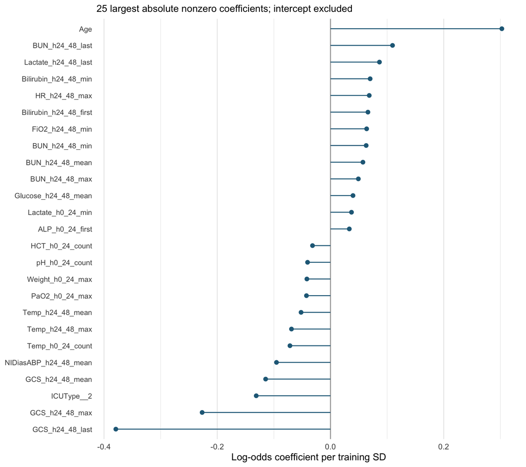

Figure 1: Largest standardized elastic-net coefficients in the all-Set-A fit.

The fit retains 51 nonzero design coefficients using tolerance `1e-8`; the figure shows the 25 largest absolute coefficients, excluding the intercept. A coefficient is the conditional log-odds change per training SD of its encoded predictor. For a dummy, one SD is not a complete category change. The largest absolute coefficient belongs to GCS_h24_48_last. These are predictive associations, not causal effects or biological discoveries.

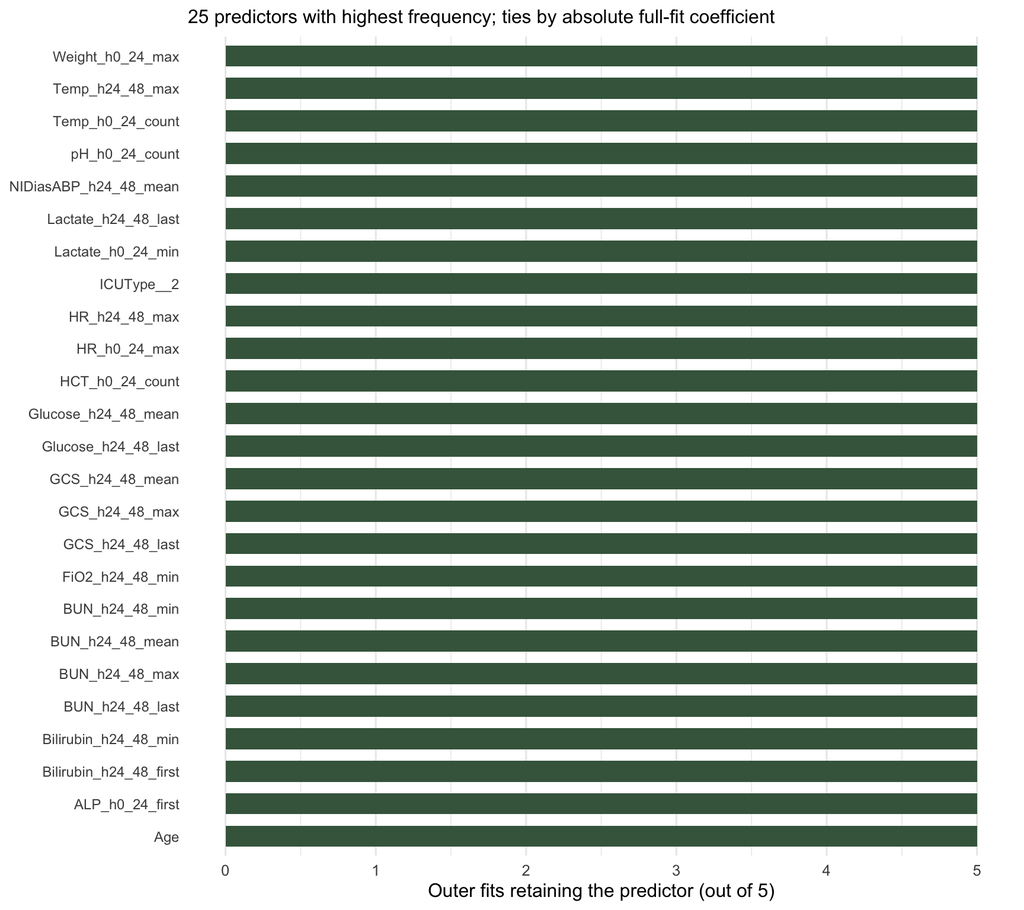

Figure 2: Predictor retention across the five outer-training elastic-net fits.

27 predictors are retained in all five outer fits; 140 appear in at least one. The figure shows the 25 highest-frequency predictors, breaking display ties by absolute full-fit coefficient. Correlated first/last/extreme/window summaries can substitute for each other, so unstable selection need not imply an absent biological association. Ordinary elastic net does not enforce selection of a whole factor.

**All encoded coefficients and retention in each outer fold**

Table 9. Full coefficient table and outer-fold retention; absent fold columns count as unretained.

| predictor | standardized_coefficient | retained | fold_1 | fold_2 | fold_3 | fold_4 | fold_5 | frequency |
| --- | --- | --- | --- | --- | --- | --- | --- | --- |
| ALP_h0_24_first | 0.03322 | TRUE | TRUE | TRUE | TRUE | TRUE | TRUE | 1.0 |
| Age | 0.30264 | TRUE | TRUE | TRUE | TRUE | TRUE | TRUE | 1.0 |
| BUN_h24_48_last | 0.10955 | TRUE | TRUE | TRUE | TRUE | TRUE | TRUE | 1.0 |
| BUN_h24_48_max | 0.04921 | TRUE | TRUE | TRUE | TRUE | TRUE | TRUE | 1.0 |
| BUN_h24_48_mean | 0.05728 | TRUE | TRUE | TRUE | TRUE | TRUE | TRUE | 1.0 |
| BUN_h24_48_min | 0.06302 | TRUE | TRUE | TRUE | TRUE | TRUE | TRUE | 1.0 |
| Bilirubin_h24_48_first | 0.06612 | TRUE | TRUE | TRUE | TRUE | TRUE | TRUE | 1.0 |
| Bilirubin_h24_48_min | 0.07003 | TRUE | TRUE | TRUE | TRUE | TRUE | TRUE | 1.0 |
| FiO2_h24_48_min | 0.06385 | TRUE | TRUE | TRUE | TRUE | TRUE | TRUE | 1.0 |
| GCS_h0_24_count | 0.00000 | FALSE | TRUE | TRUE | TRUE | TRUE | TRUE | 1.0 |
| GCS_h24_48_last | -0.37911 | TRUE | TRUE | TRUE | TRUE | TRUE | TRUE | 1.0 |
| GCS_h24_48_max | -0.22669 | TRUE | TRUE | TRUE | TRUE | TRUE | TRUE | 1.0 |
| GCS_h24_48_mean | -0.11454 | TRUE | TRUE | TRUE | TRUE | TRUE | TRUE | 1.0 |
| Glucose_h24_48_last | 0.02717 | TRUE | TRUE | TRUE | TRUE | TRUE | TRUE | 1.0 |
| Glucose_h24_48_mean | 0.03975 | TRUE | TRUE | TRUE | TRUE | TRUE | TRUE | 1.0 |
| HCT_h0_24_count | -0.03176 | TRUE | TRUE | TRUE | TRUE | TRUE | TRUE | 1.0 |
| HR_h0_24_max | 0.02379 | TRUE | TRUE | TRUE | TRUE | TRUE | TRUE | 1.0 |
| HR_h24_48_max | 0.06845 | TRUE | TRUE | TRUE | TRUE | TRUE | TRUE | 1.0 |
| ICUType__2 | -0.13114 | TRUE | TRUE | TRUE | TRUE | TRUE | TRUE | 1.0 |
| Lactate_h0_24_first | 0.00000 | FALSE | TRUE | TRUE | TRUE | TRUE | TRUE | 1.0 |
| Lactate_h0_24_min | 0.03709 | TRUE | TRUE | TRUE | TRUE | TRUE | TRUE | 1.0 |
| Lactate_h24_48_last | 0.08646 | TRUE | TRUE | TRUE | TRUE | TRUE | TRUE | 1.0 |
| NIDiasABP_h24_48_mean | -0.09539 | TRUE | TRUE | TRUE | TRUE | TRUE | TRUE | 1.0 |
| Temp_h0_24_count | -0.07160 | TRUE | TRUE | TRUE | TRUE | TRUE | TRUE | 1.0 |
| Temp_h24_48_max | -0.06890 | TRUE | TRUE | TRUE | TRUE | TRUE | TRUE | 1.0 |
| Weight_h0_24_max | -0.04170 | TRUE | TRUE | TRUE | TRUE | TRUE | TRUE | 1.0 |
| pH_h0_24_count | -0.04050 | TRUE | TRUE | TRUE | TRUE | TRUE | TRUE | 1.0 |
| AdmissionWeight | -0.00211 | TRUE | TRUE | FALSE | TRUE | TRUE | TRUE | 0.8 |
| Bilirubin_h0_24_last | 0.00000 | FALSE | TRUE | TRUE | TRUE | FALSE | TRUE | 0.8 |
| HR_h24_48_mean | 0.02958 | TRUE | TRUE | FALSE | TRUE | TRUE | TRUE | 0.8 |

[output cut: 412 more lines]

The complete table makes truncation in both figures explicit and allows checking whether full-fit retained predictors recur across folds. No post-selection Wald intervals are supplied.

## 2.5 Model 2: Logistic GAM

The GAM uses 17 clinically prespecified source variables, rather than features selected using every validation label: age, Gender, ICUType, second-window mean heart rate, temperature, mean arterial pressure (MAP) and respiratory rate; minimum GCS; last creatinine, blood urea nitrogen (BUN), white blood cell count (WBC), platelets and lactate; documented mechanical ventilation; and MAP, creatinine and lactate counts. This represents demographics, observed physiology, labs, treatment documentation and monitoring intensity. It does not assert 17 independent causal risk factors.

Table 10. Prespecified GAM source-variable set.

| predictor | window | unit | rationale |
| --- | --- | --- | --- |
| Age | time 0 | years | Demographics, body size and care setting describe case mix. |
| Gender | time 0 | 0 female / 1 male | Demographics, body size and care setting describe case mix. |
| ICUType | time 0 | 1 CCU / 2 CSRU / 3 MICU / 4 SICU | Demographics, body size and care setting describe case mix. |
| HR_h24_48_mean | [24,48] | beats/min | Average observed level summarizes window physiology. |
| Temp_h24_48_mean | [24,48] | degrees C | Average observed level summarizes window physiology. |
| MAP_h24_48_mean | [24,48] | mmHg | Average observed level summarizes window physiology. |
| RespRate_h24_48_mean | [24,48] | breaths/min | Average observed level summarizes window physiology. |
| GCS_h24_48_min | [24,48] | 3–15 score | Lowest observed value summarizes physiological extremes. |
| Creatinine_h24_48_last | [24,48] | mg/dL | Latest observed level describes the end of each window. |
| BUN_h24_48_last | [24,48] | mg/dL | Latest observed level describes the end of each window. |
| WBC_h24_48_last | [24,48] | cells/nL | Latest observed level describes the end of each window. |
| Platelets_h24_48_last | [24,48] | cells/nL | Latest observed level describes the end of each window. |
| Lactate_h24_48_last | [24,48] | mmol/L | Latest observed level describes the end of each window. |
| MechVent_h24_48_documented_1 | [24,48] | 0/1 | Recorded ventilation can reflect treatment and illness severity. |
| MAP_h24_48_count | [24,48] | records | Monitoring intensity and measurement absence can carry predictive information. |
| Creatinine_h24_48_count | [24,48] | records | Monitoring intensity and measurement absence can carry predictive information. |
| Lactate_h24_48_count | [24,48] | records | Monitoring intensity and measurement absence can carry predictive information. |

Categorical terms use the same training-defined dummy rules; continuous terms use `k = 5` basis dimensions with REML smoothness estimation. Counts enter linearly on the log1p scale, and documentation is binary. If a continuous variable has fewer than five distinct imputed training values it is linear; an unusable or constant column is dropped. The source-variable count is separate from the 20 retained encoded inputs and 54 fitted regression/spline coefficients.

The ventilation indicator equals 1 when any valid MechVent = 1 is documented in 24–48 hours. Zero means no such documentation, not proof of no ventilation. Its full-cohort documented count is 1951 stays. Median imputation is a practical way to retain rows, but may blur physiology when measurements are selective.

The following all-Set-A smooths show **centered contributions to the log odds**, with approximate 95% pointwise bands and rugs for observed, nonimputed values. Zero is a centering constraint, not a clinical threshold, absolute probability or odds ratio. The bands are conditional on this formula and imputation procedure; they do not capture all selection, missing-data or modeling uncertainty.

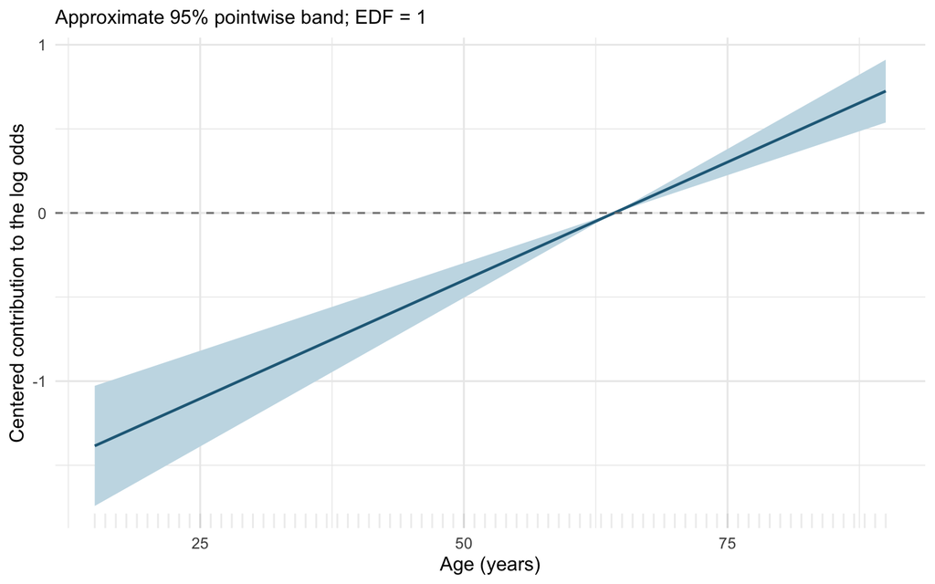

Figure 3: Age smooth: centered log-odds contribution, pointwise band and observed support.

For age, effective degrees of freedom (EDF) are 1.00. The fitted centered contribution at the 10th, median and 90th observed percentiles is respectively -0.682, 0.077, 0.584. The age contribution increases almost linearly over the observed range; EDF about one provides little evidence of nonlinearity in this fit. This is consistent with older age being associated with higher mortality conditional on the other inputs, without attributing an intervention effect to age. Bands widen toward younger and older extremes, so the fitted slope has less precision there.

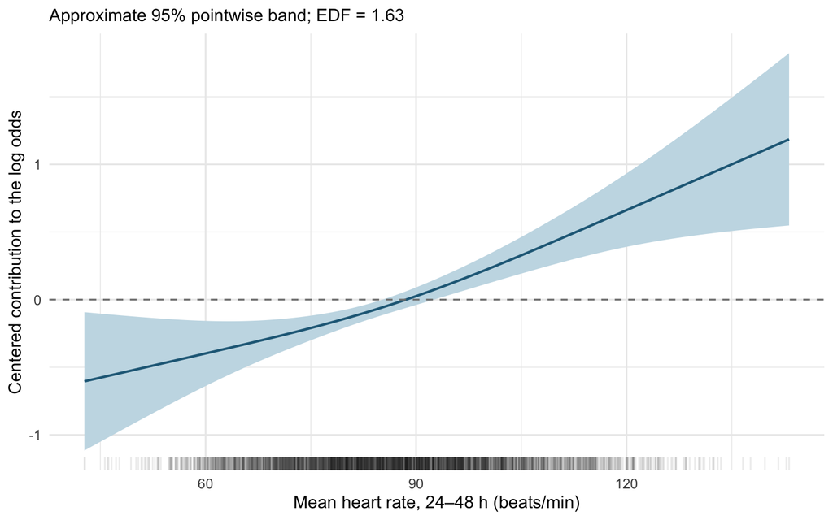

Figure 4: Second-window mean heart-rate smooth in original beats/min units.

Heart-rate EDF is 1.63. The fitted contributions at the 10th, median and 90th percentiles are -0.307, -0.043, 0.373. The fitted association increases across the observed range, with modest upward curvature rather than a U-shape. EDF about 1.63 suggests limited nonlinearity, weaker than for temperature. Higher heart rate can plausibly summarize physiological stress, but treatment and case mix may contribute to this association. Sparse low/high values have wider bands, limiting tail interpretation.

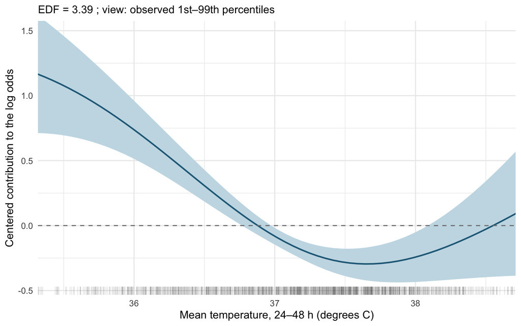

Figure 5: Second-window mean temperature smooth in original degrees C, zoomed to the observed 1st–99th percentile range; no observations are removed from fitting.

Temperature EDF is 3.39. The fitted contributions at the 10th, median and 90th percentiles are 0.485, -0.122, -0.277. The central supported range shows a declining contribution toward a trough near 37.5 degrees C, followed by an upturn at higher temperatures. EDF about 3.39 indicates more curvature than age or heart rate. This pattern is compatible with temperature departures marking illness, but it is an adjusted predictive association. The main view zooms to the observed 1st–99th percentiles; all observations remain in fitting. The full-range curve below has a poorly supported low-temperature downturn, so a simple U-shape must not be asserted over the entire range. Sparse tails, retained soft concerns and wide bands limit clinical reading.

**Temperature smooth over the full observed range**

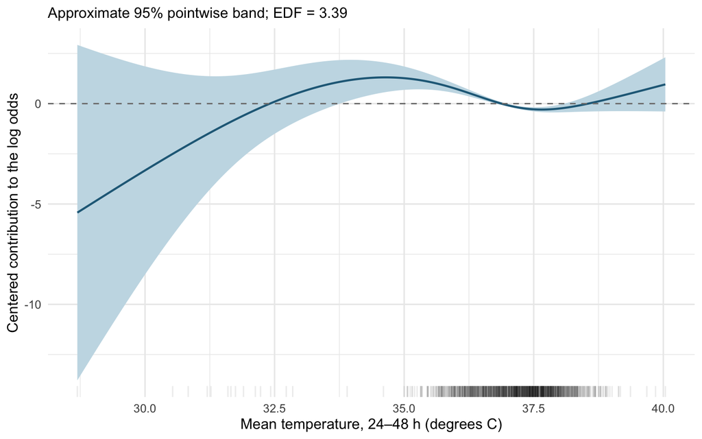

Figure 6: Untrimmed temperature range: very sparse low-temperature observations produce large uncertainty.

The untrimmed curve shows why low-temperature extrapolative-looking shapes need caution: its far-left band is much wider than in the densely observed central range. The displayed zoom changes only the view, not the data or fitted model.

Table 11. Observed support and fitted EDF for the three displayed smooths.

| variable | observed_n | imputed_n | minimum | q10 | median | q90 | maximum | edf |
| --- | --- | --- | --- | --- | --- | --- | --- | --- |
| Age | 4000 | 0 | 15.00 | 40.00 | 67.00 | 85.00 | 90.00 | 1.00 |
| HR_h24_48_mean | 3922 | 78 | 42.72 | 67.47 | 86.07 | 107.09 | 143.17 | 1.63 |
| Temp_h24_48_mean | 3912 | 88 | 28.69 | 36.30 | 37.07 | 37.86 | 40.04 | 3.39 |

The support table quantifies how many original observations versus imputed values underlie each fit. The observed range is shown without global winsorization; less-supported ranges should carry less interpretive weight.

**Convergence and basis-adequacy diagnostics**

Table 12. GAM basis checks for outer fits and all-Set-A refit.

| term | k’ | edf | k-index | p-value | context |
| --- | --- | --- | --- | --- | --- |
| s(Age) | 4 | 1.180 | 0.950 | 0.155 | outer_1 |
| s(HR_h24_48_mean) | 4 | 2.093 | 0.987 | 0.915 | outer_1 |
| s(Temp_h24_48_mean) | 4 | 3.527 | 0.940 | 0.085 | outer_1 |
| s(MAP_h24_48_mean) | 4 | 3.036 | 0.972 | 0.630 | outer_1 |
| s(RespRate_h24_48_mean) | 4 | 1.000 | 0.955 | 0.280 | outer_1 |
| s(GCS_h24_48_min) | 4 | 1.000 | 0.964 | 0.575 | outer_1 |
| s(Creatinine_h24_48_last) | 4 | 1.000 | 0.965 | 0.540 | outer_1 |
| s(BUN_h24_48_last) | 4 | 2.545 | 0.936 | 0.045 | outer_1 |
| s(WBC_h24_48_last) | 4 | 1.000 | 0.984 | 0.885 | outer_1 |
| s(Platelets_h24_48_last) | 4 | 2.051 | 0.980 | 0.815 | outer_1 |
| s(Lactate_h24_48_last) | 4 | 2.516 | 0.943 | 0.120 | outer_1 |
| s(Age) | 4 | 1.105 | 0.972 | 0.695 | outer_2 |
| s(HR_h24_48_mean) | 4 | 2.072 | 0.974 | 0.710 | outer_2 |
| s(Temp_h24_48_mean) | 4 | 3.153 | 0.943 | 0.090 | outer_2 |
| s(MAP_h24_48_mean) | 4 | 2.725 | 0.992 | 0.965 | outer_2 |
| s(RespRate_h24_48_mean) | 4 | 1.000 | 0.950 | 0.185 | outer_2 |
| s(GCS_h24_48_min) | 4 | 1.000 | 0.975 | 0.725 | outer_2 |
| s(Creatinine_h24_48_last) | 4 | 1.001 | 0.976 | 0.765 | outer_2 |
| s(BUN_h24_48_last) | 4 | 2.586 | 0.983 | 0.865 | outer_2 |
| s(WBC_h24_48_last) | 4 | 2.145 | 0.984 | 0.875 | outer_2 |
| s(Platelets_h24_48_last) | 4 | 1.881 | 0.960 | 0.405 | outer_2 |
| s(Lactate_h24_48_last) | 4 | 1.822 | 0.949 | 0.175 | outer_2 |
| s(Age) | 4 | 1.000 | 0.946 | 0.100 | outer_3 |
| s(HR_h24_48_mean) | 4 | 1.049 | 0.980 | 0.795 | outer_3 |
| s(Temp_h24_48_mean) | 4 | 3.336 | 0.983 | 0.845 | outer_3 |
| s(MAP_h24_48_mean) | 4 | 2.558 | 0.947 | 0.170 | outer_3 |
| s(RespRate_h24_48_mean) | 4 | 1.000 | 0.971 | 0.670 | outer_3 |
| s(GCS_h24_48_min) | 4 | 1.000 | 0.971 | 0.660 | outer_3 |
| s(Creatinine_h24_48_last) | 4 | 1.000 | 0.976 | 0.750 | outer_3 |
| s(BUN_h24_48_last) | 4 | 2.746 | 1.001 | 0.980 | outer_3 |
| s(WBC_h24_48_last) | 4 | 1.000 | 0.971 | 0.605 | outer_3 |
| s(Platelets_h24_48_last) | 4 | 2.625 | 0.960 | 0.345 | outer_3 |
| s(Lactate_h24_48_last) | 4 | 1.662 | 0.933 | 0.040 | outer_3 |
| s(Age) | 4 | 1.000 | 0.980 | 0.810 | outer_4 |
| s(HR_h24_48_mean) | 4 | 1.000 | 0.982 | 0.810 | outer_4 |
| s(Temp_h24_48_mean) | 4 | 3.316 | 0.948 | 0.190 | outer_4 |
| s(MAP_h24_48_mean) | 4 | 2.594 | 0.973 | 0.705 | outer_4 |
| s(RespRate_h24_48_mean) | 4 | 1.000 | 0.947 | 0.170 | outer_4 |
| s(GCS_h24_48_min) | 4 | 1.000 | 0.957 | 0.380 | outer_4 |
| s(Creatinine_h24_48_last) | 4 | 1.000 | 0.964 | 0.490 | outer_4 |
| s(BUN_h24_48_last) | 4 | 2.866 | 0.955 | 0.305 | outer_4 |
| s(WBC_h24_48_last) | 4 | 1.000 | 0.965 | 0.480 | outer_4 |
| s(Platelets_h24_48_last) | 4 | 2.362 | 0.953 | 0.270 | outer_4 |
| s(Lactate_h24_48_last) | 4 | 1.874 | 0.941 | 0.065 | outer_4 |
| s(Age) | 4 | 1.353 | 0.944 | 0.085 | outer_5 |
| s(HR_h24_48_mean) | 4 | 1.001 | 0.952 | 0.305 | outer_5 |
| s(Temp_h24_48_mean) | 4 | 3.348 | 0.946 | 0.170 | outer_5 |
| s(MAP_h24_48_mean) | 4 | 2.416 | 0.969 | 0.610 | outer_5 |
| s(RespRate_h24_48_mean) | 4 | 1.000 | 0.952 | 0.260 | outer_5 |
| s(GCS_h24_48_min) | 4 | 1.000 | 0.967 | 0.600 | outer_5 |
| s(Creatinine_h24_48_last) | 4 | 1.000 | 0.976 | 0.765 | outer_5 |
| s(BUN_h24_48_last) | 4 | 2.683 | 0.943 | 0.115 | outer_5 |
| s(WBC_h24_48_last) | 4 | 1.000 | 0.963 | 0.480 | outer_5 |
| s(Platelets_h24_48_last) | 4 | 3.275 | 0.951 | 0.285 | outer_5 |
| s(Lactate_h24_48_last) | 4 | 2.044 | 0.921 | 0.005 | outer_5 |
| s(Age) | 4 | 1.001 | 0.954 | 0.270 | full |
| s(HR_h24_48_mean) | 4 | 1.634 | 0.977 | 0.810 | full |
| s(Temp_h24_48_mean) | 4 | 3.393 | 0.950 | 0.220 | full |
| s(MAP_h24_48_mean) | 4 | 2.899 | 0.983 | 0.895 | full |
| s(RespRate_h24_48_mean) | 4 | 1.000 | 0.946 | 0.125 | full |
| s(GCS_h24_48_min) | 4 | 1.000 | 0.964 | 0.495 | full |
| s(Creatinine_h24_48_last) | 4 | 1.000 | 0.967 | 0.540 | full |
| s(BUN_h24_48_last) | 4 | 2.762 | 0.957 | 0.310 | full |
| s(WBC_h24_48_last) | 4 | 1.000 | 0.980 | 0.830 | full |
| s(Platelets_h24_48_last) | 4 | 2.466 | 0.958 | 0.315 | full |
| s(Lactate_h24_48_last) | 4 | 2.177 | 0.939 | 0.085 | full |

All fitted GAMs must pass convergence checks. Basis checks use a fixed diagnostic seed and 200 permutations. Low k-index p-values, especially with EDF near `k - 1`, can indicate inadequate basis size; the prespecified formula is not retuned using outer scores. Binary-outcome residual checks and multiple checks warrant caution. In this run, full-fit basis p-values are all above 0.05, although temperature EDF (3.39 of at most 4) merits attention. Some outer fits have low p-values for BUN and lactate, including 0.005 for lactate in fold 5; their EDFs are well below 4. These diagnostics remain a methodological limitation rather than grounds for outcome-guided formula revisions. Exact formula/fallback records are saved in `cp2_gam_terms.csv`.

Three incorrect extreme OOF GAM probabilities—one death near zero and two survivors near one—were driven by the unpenalized dummy for missing Gender. That category had only one or two outer-training stays, all with the same outcome, in the affected folds. This produced quasi-complete separation and very large coefficients despite convergence checks passing. The frozen model and AUROC comparison are retained. This is a sparse-category stability and individual-risk limitation, rather than an established input or event-coding defect. The category coefficient does not establish a causal effect, and saturated fitted probabilities must not be equated with reliable clinical risks or clinical certainty.

## 2.6 Model 3: Probability random forest

The `ranger` probability forest uses the same 449 broad candidates, training-only median imputation, categorical dummy encoding and usability dropping. It does not scale numeric columns. Predictions explicitly extract the column named `1` (death), not the survival column. Out-of-bag performance is not used for the required common-fold comparison.

The fixed grid has 500 trees, mtry rules `floor(sqrt(p))` and `floor(p/3)` (bounded to [1,p] and deduplicated within each training design), and minimum node sizes 5, 20 and 50. Here p is the retained training design dimension. Settings maximize mean three-fold inner AUROC; numerical ties favor larger node size, then smaller mtry. Bootstrap sampling with replacement uses fraction 1, Gini splits, one thread, fixed seeds and no early stopping. Missing values are explicitly imputed and the forest uses `na.action = 'na.fail'` as a safeguard.

Table 13. Selected forest settings from training-only tuning.

| context | design_p | mtry_rule | mtry | node |
| --- | --- | --- | --- | --- |
| outer_1 | 442 | sqrt | 21 | 5 |
| outer_2 | 442 | sqrt | 21 | 5 |
| outer_3 | 442 | sqrt | 21 | 5 |
| outer_4 | 442 | sqrt | 21 | 5 |
| outer_5 | 442 | sqrt | 21 | 5 |

The table shows which prespecified settings were chosen in each outer fit and, if selected as final family, the full-data tuning fit. Full grid results are saved in `cp2_tuning_forest.csv`. A training-only 500-tree smoke test took 10.605 seconds on this development machine before outer evaluation, supporting the original grid; this is a recorded development measurement, not a claim about runtime on every laptop.

## 2.7 Benchmarks, comparison and final model

SAPS-I and SOFA are used **alone as raw severity scores**, not fitted models, model predictors or calibrated probabilities. Their documented `-1` codes map to missing in evaluation copies. No logistic calibration or outcome-based benchmark imputation is performed.

Table 14. Benchmark availability among all Set A stays.

| score | available | missing |
| --- | --- | --- |
| SAPS-I | 3810 | 190 |
| SOFA | 3856 | 144 |

The primary five-method comparison uses the same 3733 score-available stays, with 520 deaths, in the existing outer folds. 267 stays lack at least one benchmark and are excluded from this comparison; every learned-model OOF prediction is still retained. The availability table makes the evaluation cohort explicit.

Table 15. Common-cohort fold AUROCs, unweighted mean and sample SD.

| Method | Fold 1 | Fold 2 | Fold 3 | Fold 4 | Fold 5 | Mean | SD | Stays | Deaths |
| --- | --- | --- | --- | --- | --- | --- | --- | --- | --- |
| Elastic net | 0.8472 | 0.8349 | 0.8288 | 0.8491 | 0.8349 | 0.8390 | 0.0088 | 3733 | 520 |
| GAM | 0.8211 | 0.8011 | 0.8184 | 0.8319 | 0.8235 | 0.8192 | 0.0113 | 3733 | 520 |
| Random forest | 0.8559 | 0.8180 | 0.8341 | 0.8479 | 0.8052 | 0.8322 | 0.0209 | 3733 | 520 |
| SAPS-I | 0.6519 | 0.6605 | 0.6791 | 0.6512 | 0.6096 | 0.6504 | 0.0254 | 3733 | 520 |
| SOFA | 0.6541 | 0.6021 | 0.6410 | 0.6252 | 0.5703 | 0.6185 | 0.0332 | 3733 | 520 |

The highest mean AUROC among learned models is for **Elastic net**. These fold values share assessment stays across methods, enabling a descriptive comparison. They remain estimates from overlapping training populations, not five independent experiments.

Table 16. Common comparison denominator and deaths in each outer fold.

| fold | n | deaths |
| --- | --- | --- |
| 1 | 748 | 105 |
| 2 | 751 | 105 |
| 3 | 743 | 102 |
| 4 | 740 | 103 |
| 5 | 751 | 105 |

These are the denominators behind every method’s fold AUROC in Table 15. This prevents a higher score from reflecting a different benchmark-available population.

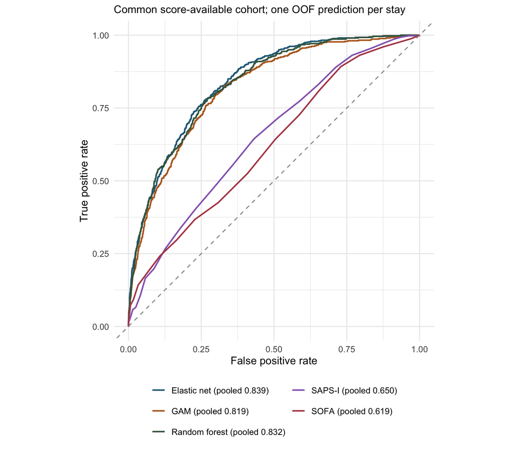

Figure 7: ROC curves for all five methods on aligned OOF predictions/raw benchmark scores.

The receiver operating characteristic (ROC) curves show discrimination over thresholds on the same stays. Pooled AUROCs in the legend summarize aligned OOF probabilities and severity scores; they do not replace the mean fold AUROCs in the main table. Scores are on different scales, so this is not a comparison of calibrated risks or actionable treatment thresholds.

Table 17. Descriptive paired fold differences: chosen model minus benchmark.

| method | mean_difference | sd_paired_difference | min_difference | max_difference |
| --- | --- | --- | --- | --- |
| SAPS-I | 0.1885 | 0.0283 | 0.1497 | 0.2253 |
| SOFA | 0.2204 | 0.0313 | 0.1878 | 0.2646 |

Compared with SAPS-I and SOFA, the chosen model’s mean differences are 0.1885 and 0.2204 respectively. The corresponding paired-difference SDs are 0.0283 and 0.0313. Here the mean gains over both raw benchmarks are larger than the corresponding paired-difference SDs and than the individual methods’ fold SDs. The improvement in discrimination is therefore large relative to this observed CV variability, but this descriptive comparison is not a significance test or evidence of clinical usefulness. Elastic net exceeds forest by only 0.0067, which is small beside their fold variation; that ranking is not persuasive evidence of superiority.

**Separate full-cohort learned-model summary**

Table 18. Full-cohort learned-model comparison, separate from the common benchmark cohort.

| method | mean_auc | sd_auc | stays | deaths |
| --- | --- | --- | --- | --- |
| Elastic net | 0.8369 | 0.0048 | 4000 | 554 |
| GAM | 0.8165 | 0.0100 | 4000 | 554 |
| Random forest | 0.8340 | 0.0210 | 4000 | 554 |

This table retains all learned-model OOF predictions, including stays without a benchmark. Its population differs from Table 15 only when benchmark scores are missing.

The final family is **Elastic net**, selected by highest common-cohort mean outer AUROC. Ties within `1e-10` favor elastic net, then GAM, then forest. The small lead over forest combines with the elastic net’s simpler prediction path and readable coefficients to support this choice; its ranking alone is not evidence of general superiority. Elastic net provides shrinkage and readable coefficients; GAM permits visual nonlinear associations; forest permits flexible interactions but has more tuning/computational cost and less direct interpretation.

Table 19. Full-data selected-family hyperparameters.

| parameter | value |
| --- | --- |
| lambda | 0.0221221629107045 |
| alpha | 0.5 |

The selected family is refitted on all Set A using its defined three-fold tuning procedure (or fixed REML for GAM), not an average of outer-fold hyperparameters. Table 19 gives the actual final settings. All-data elastic net and GAM fits are also retained for the required interpretation even if the forest wins.

`output/cp2_final_model.rds` contains the fitted estimator, fitted imputation, category fallback, design order, scaling, hyperparameters, event mapping, seeds, fold references, package versions and feature-construction specification. `cp2_predict()` takes a constructed predictor table and uses saved state without outcomes or re-estimating preprocessing. Saved/reloaded predictions agree within `1e-12` on a Set-A-derived predictor-only fixture (actual maximum absolute error 0.000000000000).

`output/cp2_oof_predictions.csv` stores one row per stay, outcome, outer fold, three OOF mortality-probability columns and two raw severity-score columns. Metrics and ROC curves use the newly written OOF CSV as their common evaluation source, so the displayed comparison can be recomputed from the saved predictions. OOF values are not replaced by all-data fitted probabilities. Applying this bundle to another dataset is outside this checkpoint.

## Reproducibility

Run `pixi run --locked checkpoint2` from the repository root with supplied Set A inputs. No earlier CP1 run, generated CSV, clinical download or personal R library is required. The report fails on R errors, sets fixed seeds, and embeds figures/resources. All generated analysis files are written under `output/`; only rendered reports are versioned among generated outputs.

The actual runtime/machine log is `output/cp2_runtime.txt`; verification commands, exit statuses, numerical checks and rendering diagnostics are documented in `docs/cp2-verification.md` and the technical execution record in `docs/cp2-submission-readiness.md`.

Table 20. Modeling warning audit for this execution.

| status | detail |
| --- | --- |
| No R modeling warnings | Convergence/path checks passed; basis diagnostics are shown separately. |

Warnings are preserved in `cp2_warnings.log`, rather than discarded. The audit above reports actual modeling warnings from this run; environment warnings and GAM basis limitations are recorded separately in verification and diagnostics.

Table 21. Versions resolved in Pixi.

| package | version |
| --- | --- |
| R | 4.5.3 |
| data.table | 1.18.6.1 |
| glmnet | 5.0 |
| mgcv | 1.9.4 |
| ranger | 0.18.0 |
| pROC | 1.19.1 |
| ggplot2 | 4.0.3 |
| knitr | 1.52 |
| tidyverse | 2.0.0 |

These are the versions used in this run. Installed package help, including `glmnet` 5.0’s control API, was checked during development; the report does not claim a development manual proves the installed API. Runtime and changing machine/date strings are kept out of this version table.

## References

- Silva I, Moody G, Scott DJ, Celi LA, Mark RG (2012). Predicting in-hospital mortality of ICU patients: the PhysioNet/Computing in Cardiology Challenge 2012. *Computing in Cardiology* 39:245–248. [Paper](https://pmc.ncbi.nlm.nih.gov/articles/PMC3965265/), [dataset and variable definitions](https://physionet.org/content/challenge-2012/1.0.0/), licensed ODC-BY 1.0.
- Friedman J, Hastie T, Tibshirani R (2010). Regularization paths for generalized linear models via coordinate descent. *Journal of Statistical Software* 33(1). [glmnet methods/documentation](https://glmnet.stanford.edu/articles/glmnet.html).
- Wood SN (2011). Fast stable restricted maximum likelihood and marginal likelihood estimation of semiparametric generalized linear models. *JRSS B* 73(1):3–36. [mgcv documentation](https://stat.ethz.ch/R-manual/R-devel/library/mgcv/html/gam.html).
- Wright MN, Ziegler A (2017). ranger: a fast implementation of random forests for high dimensional data in C++ and R. *Journal of Statistical Software* 77(1). [ranger documentation](https://imbs-hl.github.io/ranger/reference/ranger.html).
- Rozen S (2026). [Checkpoint checklist](https://steverozen.github.io/biostat707_2026/checkpoint2-3-checklist.html), [syllabus sections 9.3, 10 and 11](https://steverozen.github.io/biostat707_2026/), and [reading a centered mgcv smooth](https://steverozen.github.io/biostat707_2026/lectures/w6/w6_reading_centered_smooth.html). Live requirements checked October 10, 2026; checklist publication 2026-10-08 08:10, syllabus publication 2026-10-08 11:24. No substantive change from the supplied brief was found.